# Презентация к лабораторной работе 7

Выполнение

Власов Артем Сергеевич

1132246841@rudn.ru

Российский университет дружбы народов

# Информация

## Докладчик

- Власов Артем Сергеевич
- Студент
- Студент
- Российский университет дружбы народов им. П. Лумумбы
- 1132246841@rudn.ru
- https://vlasovas52.github.io/ru/

# Вводная часть

## Цели и задачи

Получить навыки работы с журналами мониторинга различных событий в системе. Продемонстрировать навыки умения работать с журналом мониторинга событий, созданием файла конфигурации мониторинга, journald и journalctl.

# Выполнение лабораторной работы 7

Запускаем 3 терминала, открываем во втором журнал мониторинга, на третьем пробуем получить права администратора с неверным паролем.

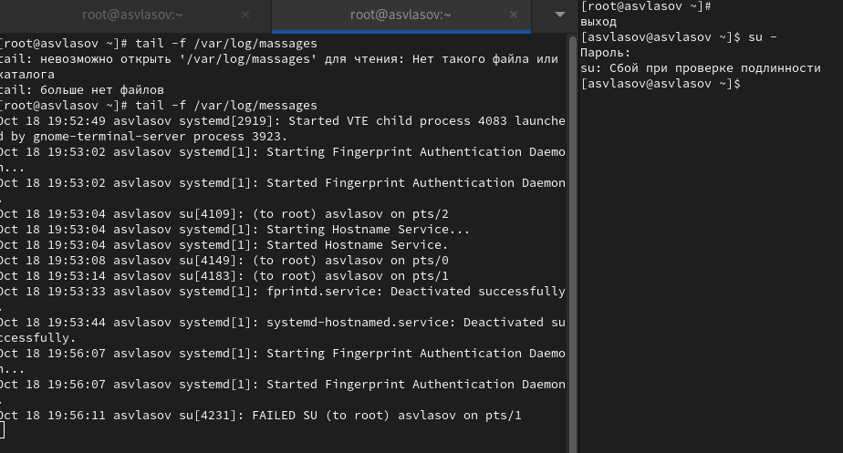

Неверный пароль администратора

Выводим в журнал сообщение hello.

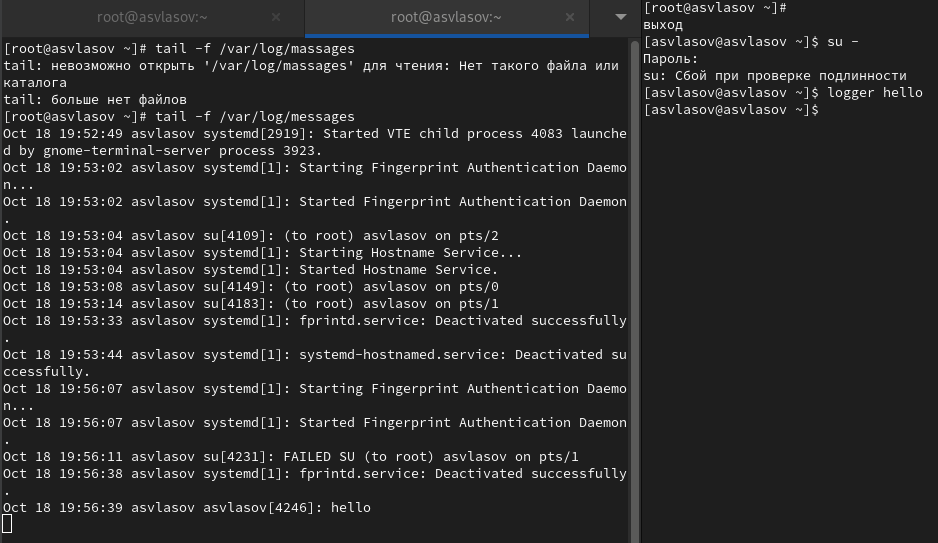

Сообщение

Открываем 20 последних строчек журнала.

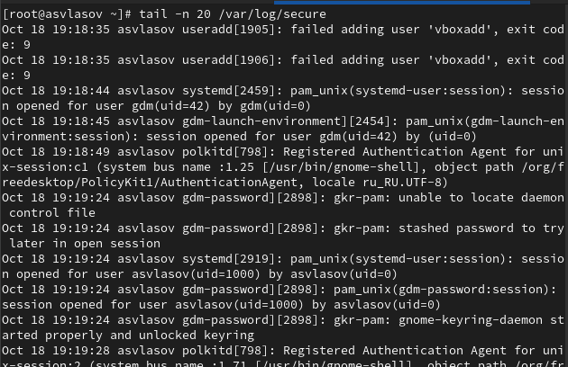

20 строчек

Устанавливаем и запускаем httpd.

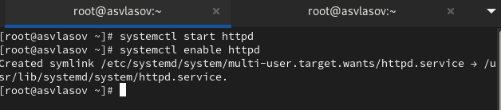

httpd

Смотрим логи ошибок httpd.

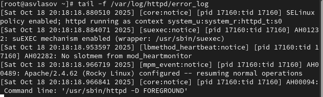

Логи ошибок

Заходим в файл конфигурации и дописываем строчку.

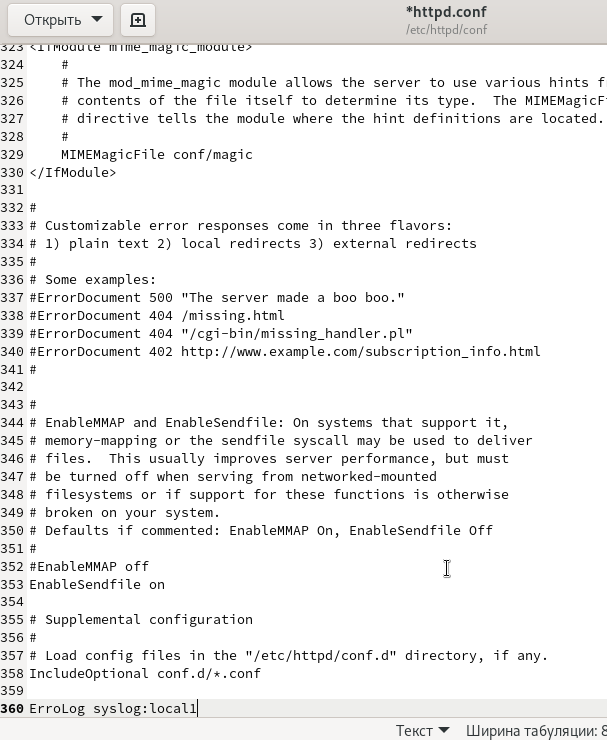

Изменение файла конфигурации

Создаем новый файл конфигурации и заполняем его.

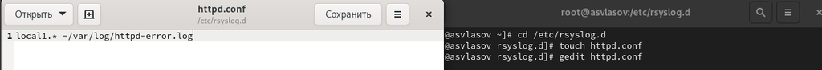

Новый файл конфигурации

Перезапускаем серивисы и дописываем строчку в файл конфигурации debug.conf.

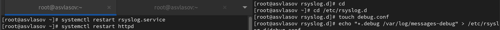

debug

Затем отправляем сообщение в дрпугой дурнал мониторинга.

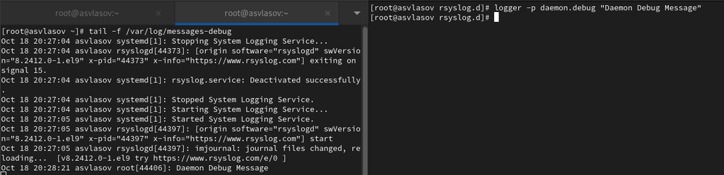

Сообщение в журнале

Начинаем работу с journalctl. Смотрим журнал в реальном времени.

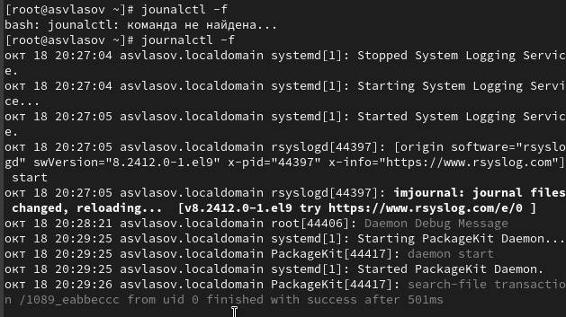

Журнал в реальном времени

Затем смотрим строки связанные с UID 0, последние 20 строк журнала и строки с ошибками.

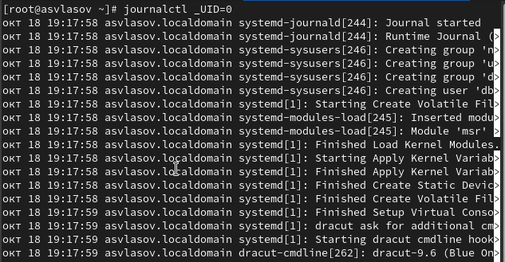

Журнал

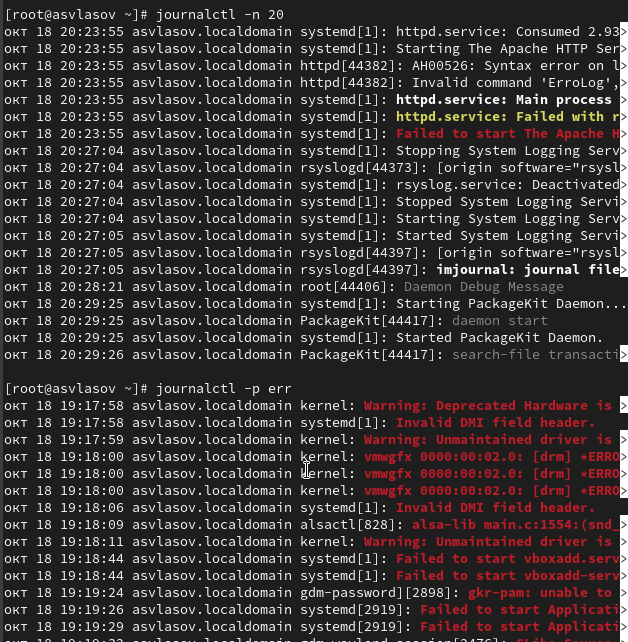

20 строк и ошибки

Смотрим все ошибки со вчерашенго дня. Просмотр детальной информации

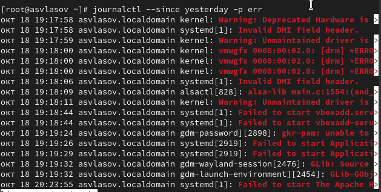

Ошибки с определенной даты

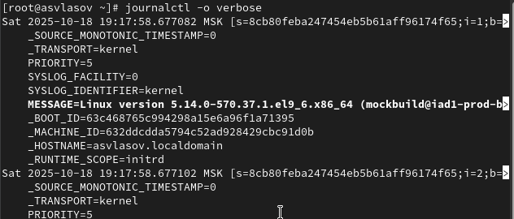

Детальная информация

Создаем каталог для хранения записей журнала, задаем ему права, принимаем изменения командой. Теперь журнал постоянный.

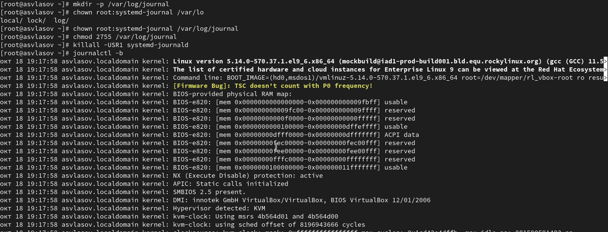

Создание постоянного журнала

# Выводы

Мы научились работать с журналами мониторинга событий в системе.